# Excess death in relation to Covid-19

12 de May, 2020

# Aim

This project aims to estimate a risk factor connected to excess death and analyse the correlation between this excess and reported cases of Covid-19.

# Data

To be able to preform analytics all data were transformed to the same structure visualized bellow. (# the are not 100% equal but though they still have the same structure).

```r
head(read.csv("data/Death_week_2_17_netherland.csv", sep = ";"))
```

|  | week | X2019 | X2018 | X2017 | X2020 | average |
| --- | --- | --- | --- | --- | --- | --- |
| 1 | 2 | 3262 | 3359 | 3637 | 3364 | 3637 |
| 2 | 3 | 3150 | 3364 | 3487 | 3152 | 3487 |
| 3 | 4 | 3178 | 3322 | 3626 | 3041 | 3626 |
| 4 | 5 | 3143 | 3403 | 3574 | 3158 | 3574 |
| 5 | 6 | 3185 | 3513 | 3446 | 3189 | 3446 |
| 6 | 7 | 3252 | 3660 | 3417 | 3195 | 3417 |

# Model

The distribution used will be (# this might have to change)

$$(1)\hspace{0.3cm}O_i \sim Poisson(E_i\theta_i).$$

Hence the model will estimate the risk factor $\theta_{i,2020}$. If 1 is outside of the credibal intervals the risk will be considerd significant and we can assume there is a precanse of exsess death.

The $log(\theta_i)$ are assumed to follow a normal distribution with parameters

$log(\theta_i) \sim Normal(\mu_i,\sigma_i)$ (#this might also change slightly)

with $\mu_i$ and $\sigma_i$ again are normaly distributed with shared hyperparameters.

# Analysis

Reading the data

```r
data_netherland<- read.csv("data/Death_week_2_17_netherland.csv", sep = ";")
data_england_wales <- read.csv("data/England_Wales_weekly.csv",sep = ";")
data_italy <- read.csv("data/italy_week_deaths.csv", sep = ",")
data_norway<- read.csv("data/Norway_total_death.csv", sep = ";")
```

Extracting the data for the Netherland

```r
mean_netherland <- as.vector(as.matrix(data_netherland)[,6])
netherland_2020<-as.vector(as.matrix(data_netherland)[,5])
```

Extracting data England and Wales

```r
mean_england <- as.vector(as.matrix(data_england_wales)[,12])
england_2020 <- as.vector(as.matrix(data_england_wales)[,13])
```

Extracting data Italy

```r
mean_italy <- as.vector(as.matrix(data_italy)[,9])
italy_2020 <- as.vector(as.matrix(data_italy)[,8])
```

Extracting the data for Norway

```r
mean_norway <- as.vector(as.matrix(data_norway)[,8])
norway_2020<-as.vector(as.matrix(data_norway)[,7])
```

### Setting up the stan lists

```r
N_netherland <- length(mean_netherland)
data_list_netherland <- list(
  N = N_netherland,
  E = mean_netherland,
  O = netherland_2020,
  mu1 = 0,
  mu2 = 0,
  sigma1 = 100,
  sigma2 = 10
  )
```

```r
N_england <- length(mean_england)
data_list_england_wales <- list(
  N = N_england,
  E = mean_england,
  O = england_2020,
  mu1 = 0,
  mu2 = 0,
  sigma1 = 100,
  sigma2 = 10
  )
```

```r
N_italy <- length(mean_italy)
data_list_italy <- list(
  N = N_italy,
  E = mean_italy,
  O = italy_2020,
  mu1 = 0,
  mu2 = 0,
  sigma1 = 100,
  sigma2 = 10
  )
```

```r
N_norway <- length(mean_norway)
data_list_norway <- list(
  N = N_norway,
  E = mean_norway,
  O = norway_2020,
  mu1 = 0,
  mu2 = 0,
  sigma1 = 100,
  sigma2 = 10
  )
```

Fit the stan models

```r
risk_netherland <- stan(params$stanfile, iter = params$iter, chains = 4,
  data = data_list_netherland, seed = 1)
```

```
## Trying to compile a simple C file
```

```r
risk_england_wales <- stan(params$stanfile, iter = params$iter, chains = 4,
  data = data_list_england_wales, seed = 1)

risk_italy <- stan(params$stanfile, iter = params$iter, chains = 4,
  data = data_list_italy, seed = 1)

risk_norway <- stan(params$stanfile, iter = params$iter, chains = 4,
  data = data_list_norway, seed = 1)
```

# Results

### Netherland

Backtransform the results form log to normal

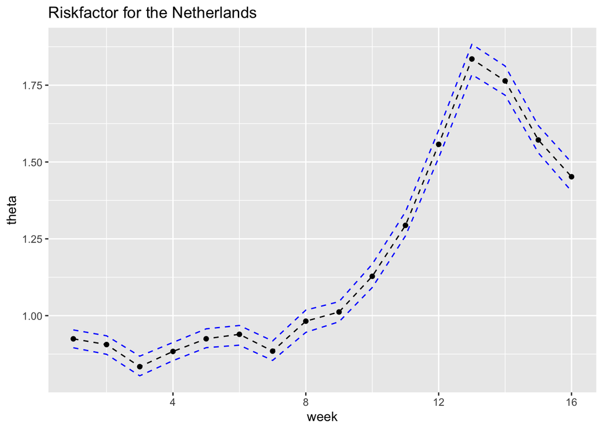

```r
week = seq(1:16)

ggplot(data = data.frame(week, CI_upper, CI_lower, theta), aes(x = week, y = theta)) + geom_point() + geom_line(lty = 2) +
  geom_line(aes(week, CI_lower), col = "blue", lty = 2) +
  geom_line(aes(week, CI_upper), col = "blue", lty = 2) +
  ggtitle("Riskfactor for the Netherlands")
```

### England and Wales

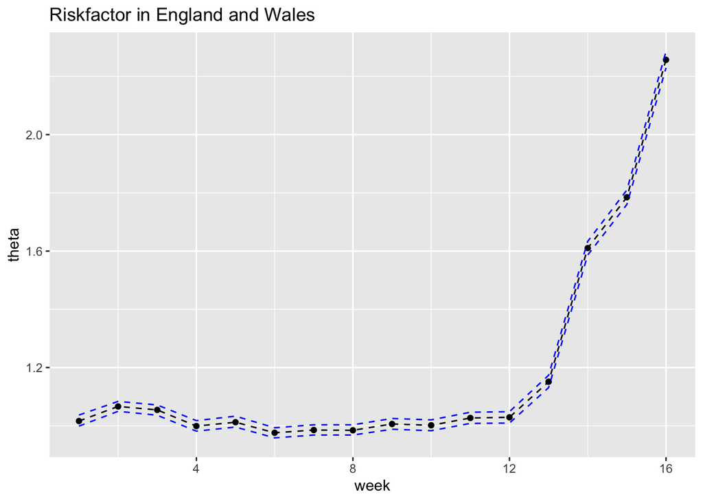

```r
week = seq(1:16)

ggplot(data = tibble(week, CI_upper, CI_lower, theta), aes(x = week, y = theta)) + geom_point() + geom_line(lty = 2) +
  geom_line(aes(week, CI_lower), col = "blue", lty = 2) +
  geom_line(aes(week, CI_upper), col = "blue", lty = 2) +
  ggtitle("Riskfactor in England and Wales")
```

# Italy

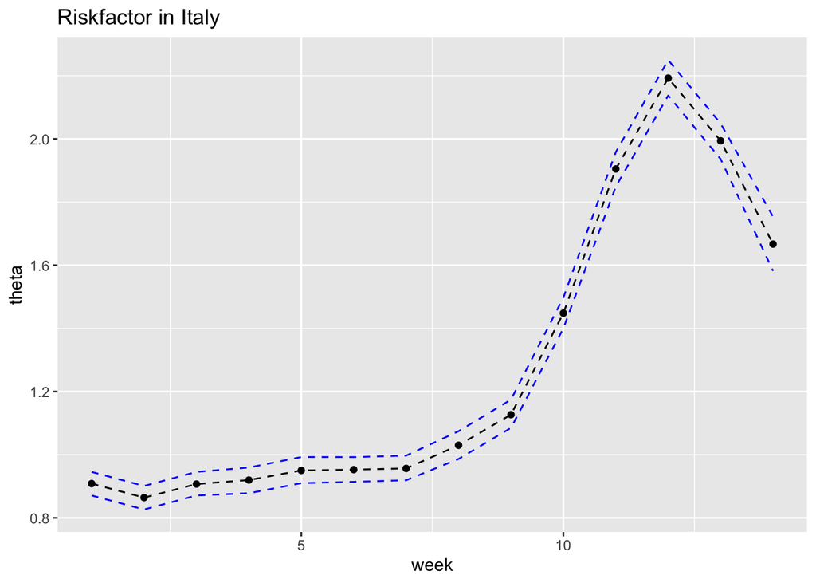

```r
week = seq(1:14)

ggplot(data = data.frame(week, CI_upper, CI_lower, theta), aes(x = week, y = theta)) + geom_point() + geom_line(lty = 2) +
  geom_line(aes(week, CI_lower), col = "blue", lty = 2) +
  geom_line(aes(week, CI_upper), col = "blue", lty = 2) +
  ggtitle("Riskfactor in Italy")
```

# Norway

Backtransform the results form the logscale

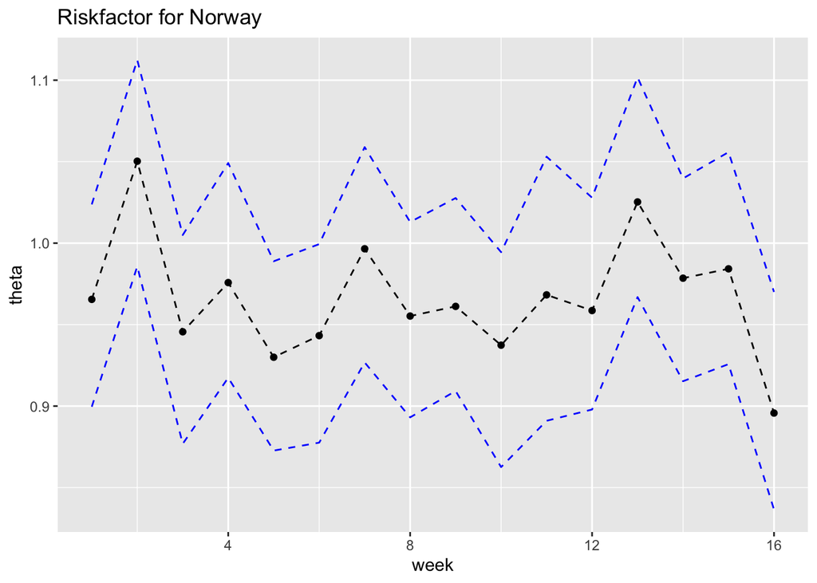

```r
week = seq(1:16)

ggplot(data = tibble(week, CI_upper, CI_lower, theta), aes(x = week, y = theta)) + geom_point() + geom_line(lty = 2) +
  geom_line(aes(week, CI_lower), col = "blue", lty = 2) +
  geom_line(aes(week, CI_upper), col = "blue", lty = 2) +
  ggtitle("Riskfactor for Norway")
```

# Possible extentions

To extend the model one could explore an hierarchical model adding the different countries to the same model, add explanatory variables for the risk $\theta_i$ (% of elderly people, % smokers, % obecity, % time of lockdown).

$log(\theta_i) \sim Normal(\beta_i + \beta_1 X_1 + \beta_2 X_2,\sigma_i^2)$

One could also explore the timedependesy for example by implementing an auto regressive model.

Also we would like to explore the possibility of doing the same model with E_i changing to the historical average plus the number of registered covid-19 deaths. Then the risk factor theta could share some light on how much unexplaind death occures in the different countries.